# Session 4

Ecological Data Collection and Processing: Exercises

Ward Fonteyn & Stef Haesen

04/11/2021

## Feedback assignment 3

- Data exploration is always first step
- Make sure you can relate back to plot number
- Dissimilarity is mirrored so divide by two!

# Session 4: Relationships

## Format

- Make small groups
- Work through the question together and discuss which method should be used
- After the given time one group explains their solution

## Exercises for today

Case studies:

- Choosing the correct statistical test given a research question and a dataset
- Extracting the results from R

## Question 1 (20 min)

Common beech (Fagus sylvatica) is increasing in Forêt de Compiegne (N. France) and we want to know if it has an effect on the forest understory species. We have sampled the understory in 26 forest plots. Some plots with, other without Fagus in the overstory.

*Research question: Does Fagus sylvatica (common beech) have an effect on the understory cover in temperate forests?*

Use the Compiegne datasets. The Understory cover is the sum of all species individuals:

```r
library(edcpR)
data(Compiegne_env, Compiegne_sp, package = "edcpR")
```

## Solution Question 1

```r
Understory_cover <- rowSums(Compiegne_sp[2:dim(Compiegne_sp)[2]])
Compiegne <- data.frame(plot = Compiegne_env$plot,
                        Fagus = Compiegne_env$Fagus,
                        Understory_cover = Understory_cover)
head(Compiegne)
```

```
##   plot Fagus Understory_cover
## 1    1     0               93
## 2    2     1              106
## 3    3     0               52
## 4    4     0              114
## 5    7     1              102
## 6    8     0               93
```

## Solution Question 1 (2)

Point-biserial correlation coefficient (rp)

- One variable in binary form
- 2nd variable in quantitative form

## Solution Question 1 (3)

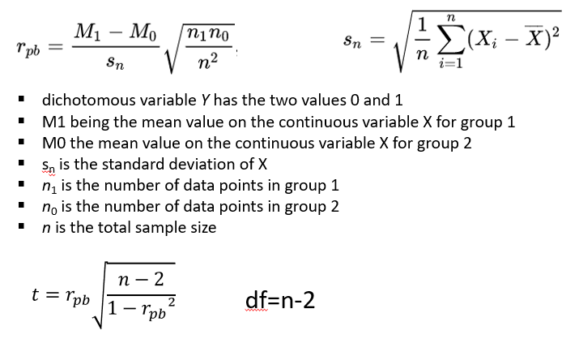

## Solution Question 1 (4)

```r
X = Compiegne$Understory_cover
Y = Compiegne$Fagus

n <- length(Y)

a = sqrt((sum(Y)*(n-sum(Y)))/(n^2))
sn <- sqrt((1/(n))*sum((X- mean(X))^2))

rpb = a*(mean(X[Y==1])-mean(X[Y==0]))/sn
rpb # very weak correlation
```

```
## [1] 0.0906891
```

```r
t <-  rpb*sqrt((n-2)/(1-rpb^2))
pt(t, n-2) # Not significant
```

```
## [1] 0.6702461
```

## Solution Question 1 (5)

```r
cor.test(Compiegne$Fagus, Compiegne$Understory_cover)
```

```
##
##  Pearson's product-moment correlation
##
## data:  Compiegne$Fagus and Compiegne$Understory_cover
## t = 0.44612, df = 24, p-value = 0.6595
## alternative hypothesis: true correlation is not equal to 0
## 95 percent confidence interval:
##  -0.3074636  0.4618180
## sample estimates:
##       cor
## 0.0906891
```

```r
biserial.cor(Compiegne$Understory_cover, Compiegne$Fagus, level = 2)
```

```
## [1] 0.0906891
```

## Question 2 (20 min)

We want to study the relationship between different soil variables to gain more insight in soil processes in Finnish marshes.

*Research question: Is there a relationship between soil Ca content and soil pH?*

Use the varechem dataset:

```r
library(vegan)
data(varechem, package = "vegan")
```

## Solution Question 2 (1)

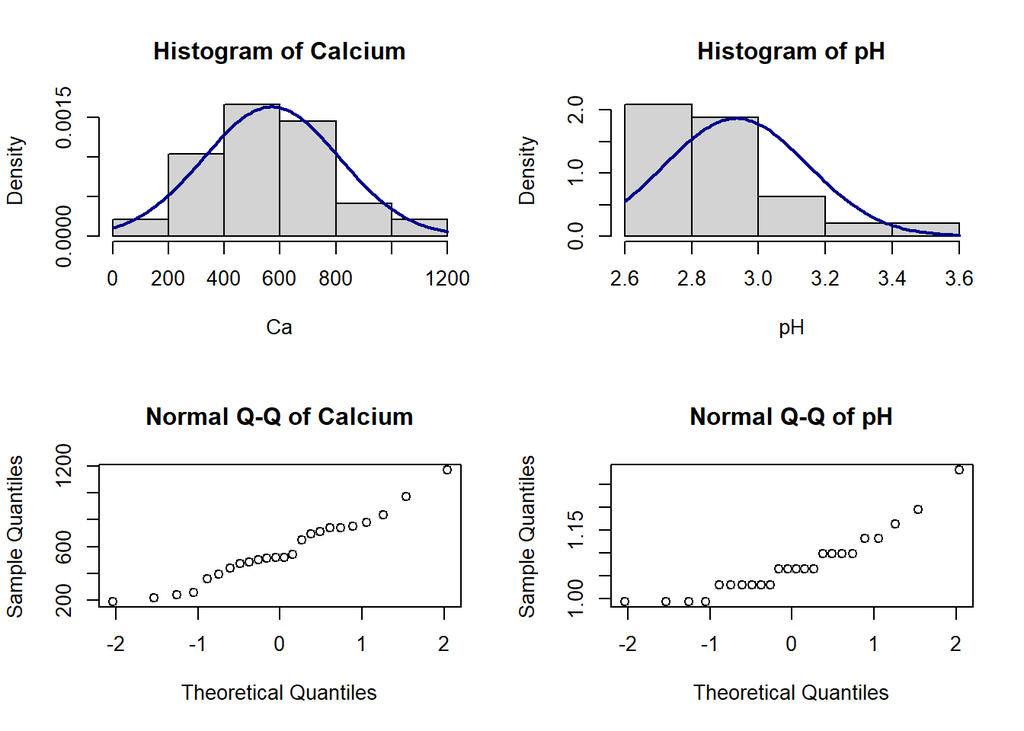

## Solution Question 2 (2)

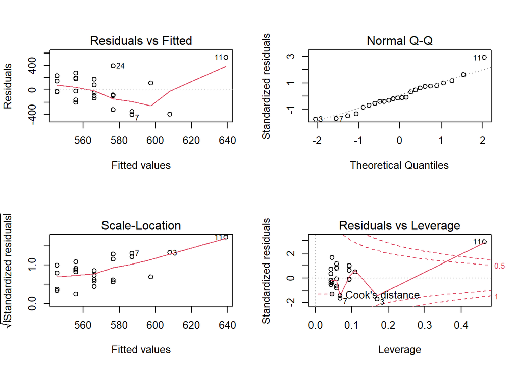

## Solution Question 2 (3)

```r
n <- length(varechem$Ca)
di <- rank(varechem$Ca, ties.method = "average") - rank(varechem$pH, ties.method = "average")

rs <-  1 - (6*sum(di^2))/(n*(n^2-1)) # r-squared
rs # Weak correlation
```

```
## [1] -0.2304348
```

```r
t <- rs*sqrt((n-2)/(1-rs^2)) # Test statistic
pt(t, n-2) # not significant
```

```
## [1] 0.1393392
```

## Solution Question 2 (4)

```r
cor.test(varechem$Ca, varechem$pH, method = "spearman")
```

```
##
##  Spearman's rank correlation rho
##
## data:  varechem$Ca and varechem$pH
## S = 2877.6, p-value = 0.2365
## alternative hypothesis: true rho is not equal to 0
## sample estimates:
##        rho
## -0.2511407
```

## Solution Question 2 (5)

You can use the pearson correlation if:

- Variables are quantitative
- Linear relationship between two variables
- No outliers
- Normal distribution of variables
- Homoscedasticity
- Observations of X and Y are independent

## Question 3 (15 min)

Using the dune_spec dataset:

*Research question: Is the species composition of a haypasture dune grassland closer to a hayfield dune grassland or to pasture dune grassland?*

```r
data(dune_spec, package = "edcpR")
```

## Solution Question 3

```r
vegdist(dune_spec[,-1],method = "bray")
```

```
##           1         2
## 2 0.6393443
## 3 0.5517241 0.2289157
```

## Question 4 (15 min)

Using the varechem dataset:

*Research question: How do the soil conditions compare between the plots?*

```r
data(varechem, package = "vegan")
```

## Solution Question 4 (1)

```r
# Baresoil, is not a soil condition, so it can just be deleted from the data frame
varechem <- varechem %>% select(-Baresoil)
head(varechem)
```

```
##       N    P     K    Ca    Mg    S    Al   Fe    Mn   Zn  Mo Humdepth  pH
## 18 19.8 42.1 139.9 519.4  90.0 32.3  39.0 40.9  58.1  4.5 0.3      2.2 2.7
## 15 13.4 39.1 167.3 356.7  70.7 35.2  88.1 39.0  52.4  5.4 0.3      2.2 2.8
## 24 20.2 67.7 207.1 973.3 209.1 58.1 138.0 35.4  32.1 16.8 0.8      2.0 3.0
## 27 20.6 60.8 233.7 834.0 127.2 40.7  15.4  4.4 132.0 10.7 0.2      2.9 2.8
## 23 23.8 54.5 180.6 777.0 125.8 39.5  24.2  3.0  50.1  6.6 0.3      3.0 2.7
## 19 22.8 40.9 171.4 691.8 151.4 40.8 104.8 17.6  43.6  9.1 0.4      3.8 2.7
```

```r
# Standardize variables
varechem_scale <- as.data.frame(scale(varechem))
```

## Solution Question 4 (1)

```r
# Euclidian distance
euclidean <- vegdist(varechem_scale, method = "euclidean")
euclidean <- scores(euclidean)

# Some possible conclusions...
which(euclidean == min(euclidean[euclidean > 0]), arr.ind=TRUE)
```

```
##    row col
## 12  21   2
## 15   2  21
```

```r
which(euclidean == max(euclidean), arr.ind=TRUE)
```

```
##    row col
## 3   17   3
## 24   3  17
```

## Assignment

**NO** Assignment this week.

**Next session** assignment on this and the next exercise session.